# act_report

## Udacity Project Wrangle Data

### We Rate Dogs Twitter Data - Analysis Report

### Introduction

As part of this report I have used data from the We Rate Dogs Twitter account to analyse tweets. This twitter accounts rates dogs, they receive images from followers on people's dogs and the account tweets a rating based on the image provided also adding in a comical caption in reference to the image.

The purpose of this analysis was to use the basic tweet data provided as art of the WeRateDogs Twitter Archive, combine this data with a data source that was created to predict the breed of dog and attaches an image to each tweet. I have also downloaded data on retweets, favourite counts using the help of the Twitter API and combine all of the source together to produce some interesting insights about the data.

Having assessed the data for any quality and tidiness issues the three sources were combined into one final table to create the below insights.

#### Insight 1

One of the first insights I looked into was to determine out of the different sources that can be used to post tweets, which of these is most popular. As per the analysis the most popular method is to Twitter on the iPhone.

#### Insight 2

An interesting insight was also to analyse the different life stages of the dogs and determine of the tweets which life stage are most of the dogs in. From the data I was able to understand that most of the dogs and in the pupper life stage.

#### Insight 3

I was also interested in seeing what is the most popular dog name out of all the tweets that had been posted. I have created a bar chart to illustrate this analysis:

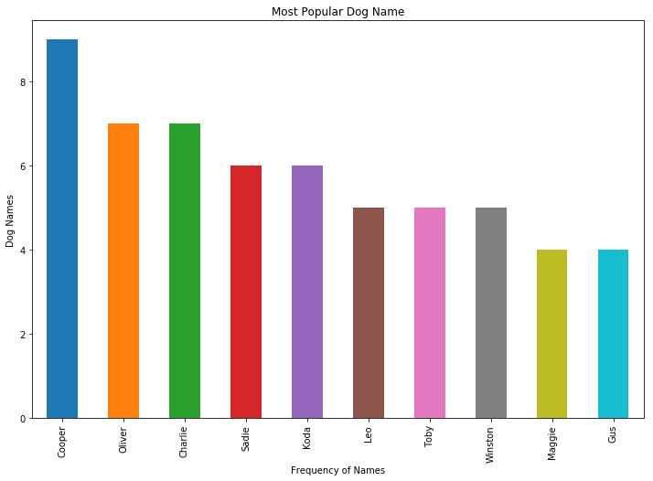

Based on the barchart above we can see the most popular dog name is Cooper.

#### Insight 4

Having analysed dog names, and it made sense to also determine from the tweets which dog breed is most popular. I have created a histrogram to analyse the most rate dog breed as per below:

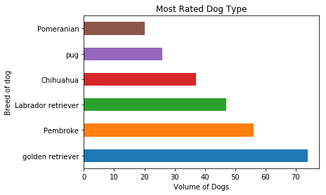

The Golden Retriever dog is the most rated dog breed.

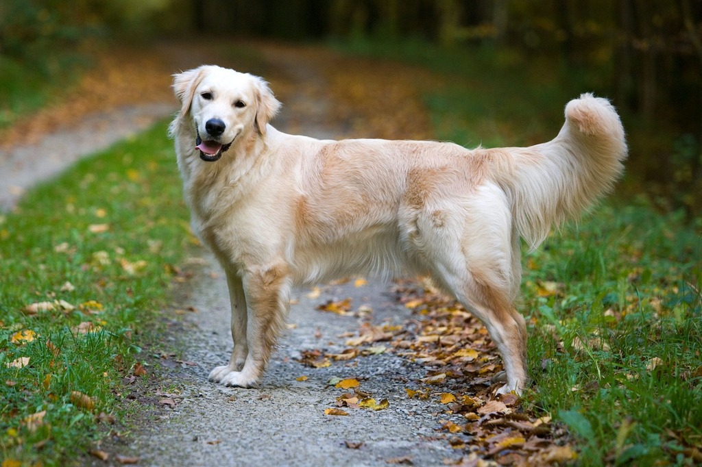

#### Insight 5

The last insight I have created is a comparison of the volume of favourited tweets to the volume of retweets. I was interested in seeing if there is a relationship between these two variables. A scatter plot below displays the findings:

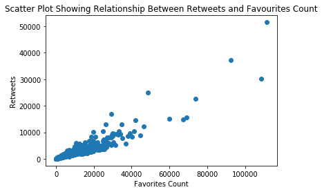

As can be seen from the scatter plot above there appears to be a strong positive relationship between the retweets and the favorites count.